# UMA ANÁLISE DE PARTE DO ELEITORADO BOLSONARISTA EM 2018

Diego Cavalcante e Yury Machado

### RESUMO

O presente trabalho buscou investigar parte do perfil do eleitorado que elegeu o presidente Jair Bolsonaro nas eleições de 2018. A partir de uma breve descrição de sua trajetória política, de leitura de conjuntura da campanha eleitoral, de discussão teórica e de análise de dados, foram utilizadas técnicas quantitativas para a análise multivariada de dados, estes, oriundos do survey pós-eleitoral Estudo Eleitoral Brasileiro, de 2018, de onde foram selecionadas opiniões do eleitorado de Bolsonaro acerca de algumas instituições democráticas, a saber, Governo Federal, Poder Judiciário, Partidos Políticos, Congresso Nacional, Forças Armadas e Democracia. Foi possível verificar que a maior parte do eleitorado de Jair Bolsonaro possui pouca ou nenhuma confiança nas instituições democráticas analisadas. Por uma perspectiva desagregada, as FFAA figuram como a instituição que goza de maior confiança dessa parcela do eleitorado. O governo federal goza de relação negativa com a chance de voto em Jair Bolsonaro, bem como o Judiciário, Congresso Nacional e Partidos Políticos possuem relação positiva com o voto no Presidente.

Palavras-chave: Eleição Presidencial; Autoritarismo; Jair Bolsonaro; Instituições Democráticas.

### INTRODUÇÃO

O presente trabalho buscou analisar o perfil do eleitorado do presidente Jair Bolsonaro, eleito em 2018, verificando e relacionando suas percepções quanto às instituições democráticas a partir dos dados do Estudo Eleitoral Brasileiro (ESEB), um survey pós-eleitoral de cunho acadêmico, realizado pelo Centro de Estudos em Opinião Pública desde 2002, sendo um projeto vinculado ao Comparative Study of Electoral Systems Project (CSES) , amplamente utilizado em trabalhos acadêmicos da área de comportamento eleitoral e opinião pública autores da ciência política brasileira.

O resultado da eleição para a Presidência da República de 2018 no Brasil representa uma mudança de rota na política nacional, visto que deu-se uma ruptura na hegemonia eleitoral do Partido dos Trabalhadores (PT) e do Partido da Social Democracia Brasileira (PSDB), que venceram 6 (seis) eleições consecutivas para o cargo. Nesse cenário, torna-se importante investigar quais foram os fatores associados à vitória eleitoral de Jair Bolsonaro (à época, PSL, e atualmente sem partido), um parlamentar veterano, sempre considerado de “baixo clero”, mas que ocupa o cargo representativo mais relevante do país.

Apesar da risível influência política na Câmara dos Deputados, a visibilidade de Bolsonaro se dá a partir da ressonância de seus posicionamentos polêmicos, proferidos em programas de televisão e na internet, em especial nas redes sociais. Algumas manifestações que alcançam maior destaque são as que expressam o saudosismo pelo período da ditadura militar, ocorrida no Brasil entre 1964 e 1985. Em certa ocasião, no programa “Câmara Aberta”, da TV Bandeirantes, em 1999, o então deputado federal defendeu o fechamento do Congresso Nacional e opinou que a ditadura militar deveria ter assassinado cerca de 30 mil corruptos, começando pelo Presidente da República em exercício à época da entrevista, a saber, Fernando Henrique Cardoso.

Outras falas saudosas ao período ditatorial brasileiro podem ser identificadas em situações mais recentes. No dia 31 de março de 2016, ocasião em que se completava 52 anos do início da ditadura militar brasileira, Bolsonaro publicou um vídeo na sua conta do Twitter no qual dizia que “[…] devemos sim, comemorar essa data […] Afinal de contas, foi um novo 7 de setembro”. No mesmo ano, durante a sessão de votação do impeachment da então presidente Dilma Rousseff, o ex-deputado homenageou o coronel Carlos Alberto Brilhante Ustra, o primeiro militar reconhecido pela Justiça Brasileira como torturador durante a ditadura militar.

Esse posicionamento não mudou no decorrer do período de campanha eleitoral. Em julho de 2018, no programa Roda Viva da TV Cultura, Bolsonaro declarou que não houve golpe militar em 1964, já que, em sua narrativa, a repressão deste período foi apenas uma resposta aos desafios políticos da época, impostos pela corrupção e pelo avanço de uma esquerda comunista, bem como uma solução eficaz para a segurança pública. Ainda durante a campanha, o capitão retoma sua narrativa negacionista no programa de TV Jornal da Band, da emissora TV Bandeirantes, voltando a afirmar que “hoje em dia grande parte da população entende que o período militar não foi ditadura, como a esquerda sempre pregou”.

As produções científicas sobre a adesão dos cidadãos à democracia ou às formas autoritárias de regime político possuem extenso histórico no campo de pesquisas sobre comportamento político, sendo The Civic Culture, de Almond e Verba (1963), a obra fundante. Diversas obras a sucederam e contribuíram para um avanço considerável na literatura especializada. Rose (2002), por exemplo, contribui para compreender atitudes e comportamentos em relação à democracia em países classificados como “novas democracias”, isto é, aqueles que se tornaram democráticos a partir da terceira onda de democratização (HUNTINGTON, 1995). O autor sustenta que, em novas democracias, é necessário comparar as preferências dos cidadãos em relação a diversos tipos de regimes políticos e não somente à democracia, uma vez que algumas gerações viveram boa parte de suas vidas sob um regime distinto. Dessa forma, há memória e, consequentemente, apreciações sobre um regime político autoritário anterior, sendo razoável medir em surveys a preferência pela democracia comparando-a com o autoritarismo, a fim de se analisar a robustez da legitimidade democrática.

No âmbito da América Latina, Lagos (2000) tornou-se uma referência. A autora argumenta que o passado de colonização, exploração econômica, patrimonialismo e, mais recentemente, de autoritarismo político, nos países da América Latina criou-se uma identidade coletiva na qual os cidadãos, apesar de majoritariamente preferirem a democracia, não se mostram satisfeitos com ela. À essa situação dos latino-americanos de manterem-se em silêncio frente às insatisfações da vida em sociedade a autora dá o nome de “máscara sorridente”.

Outros estudos empíricos realizados na América Latina levaram a conclusões semelhantes às obtidas por Lagos. Ao aplicar a Escala de Autoritarismo de Direita (EAD) no Brasil, Vilanova et al. (2018) observa que grande parte dos cidadãos apresentam traços de submissão acrítica a autoridades, de modo semelhante aos EAD aplicados em outros países da América Latina, em especial os que compartilham o passado autoritário do Brasil. Veiga et al. (2016) observam também que essas tendências antidemocráticas são mais comuns em nações que possuem democracias recentes, de modo que, quanto mais tempo ininterrupto as democracias possuem, mais a população a vê positivamente e apoia seus valores centrais e suas instituições.

No mesmo sentido, achados mais recentes de Fuks et al. (2019) também evidenciam uma maior coerência entre o apoio democrático e a internalização de valores democráticos essenciais nos regimes com mais anos ininterruptos de democracia. Além disso, o estudo mostra que a quantidade de indivíduos considerados democratas coesos, ou seja, aqueles que não só apoiam o sistema político mas praticam seus valores centrais, é significativamente baixo nos países latino-americanos.

Algo semelhante também é observado no Brasil por Braga e Casalecchi (2016). O estudo aponta que, na eleição presidencial de 2014, o eleitorado “perdedor” manteve o apoio à democracia, porém, houve um significativo aumento de insatisfação com o funcionamento do regime democrático entre eles.

### MÉTODO

A verificação empírica das hipóteses estabelecidas até aqui utilizou-se de técnicas quantitativas de análise de dados, de natureza estatística multivariada, por meio de regressões logísticas binárias, a fim de investigar a relação entre determinadas opiniões e comportamentos e a escolha do voto para presidente da república em 2018, tanto em primeiro quanto em segundo turno, tendo a opção pela candidatura de Bolsonaro como foco. Os resultados obtidos através da regressão logística são dados em razão de chances (odds ratio).

A coleta dos dados foi realizada através do Estudo Eleitoral Brasileiro (ESEB, um survey pós-eleitoral de cunho acadêmico, realizado pelo Centro de Estudos em Opinião Pública desde 2002, sendo um projeto vinculado ao Comparative Study of Electoral Systems Project (CSES), amplamente utilizado em trabalhos acadêmicos da área de comportamento eleitoral e opinião pública autores da ciência política brasileira. O ESEB 2018 é composto por 2506 entrevistas, realizadas em domicílio com eleitores brasileiros de 172 cidades e 27 estados brasileiros. As entrevistas ocorreram entre os dias 10 e 24 de novembro de 2018, ou seja, em período pós-eleitoral. Para a amostra, são utilizadas quotas de sexo, idade, grau de escolaridade, ramo de atividade e número de banheiros no domicílio, baseadas em dados do Instituto Brasileiro de Geografia e Estatística (IBGE). Desta forma, a margem de erro atribuída ao estudo é 2,2% e seu intervalo de confiança é de 95%.

Para fins de obtenção dos objetivos propostos no trabalho, foram selecionadas perguntas e respostas ao eleitorado a respeito do grau de confiança sobre algumas instituições democráticas brasileiras, a saber, Governo Federal (P404), Poder Judiciário (P405), Partidos Políticos (P407), Congresso Nacional (P408) e Forças Armadas (P409). As respostas para essas questões estão dispostas no banco de dados em valores de 1 a 4, de modo que, 1 indica muita confiança, 2 representa alguma confiança, 3 é atribuída a pouca confiança e 4 à nenhuma confiança. Sobre estas, foi criado um índice de confiança nas instituições democráticas. Ainda, foi verificado o grau de confiança dos eleitores nas Forças Armadas separadamente, por se tratar do “nicho” social e profissional de origem do presidente Bolsonaro, a fim de analisar se há uma adesão eleitoral baseada nessa relação de origem.

### RESULTADOS

Nesta seção são descritos os principais resultados dos testes estatísticos inferenciais, referentes à indicação de voto em Bolsonaro nos dois turnos da eleição presidencial de 2018, e com foco nas respostas às hipóteses construídas.

A Gráfico 1 apresenta o índice de confiança nas instituições democráticas em histograma, criado a partir da soma dos valores atribuídos ao Governo Federal, Poder Judiciário, Partidos Políticos, Congresso Nacional e Forças Armadas, indo de muita confiança a nenhuma confiança.

**GRÁFICO 1 - ÍNDICE DE CONFIANÇA**

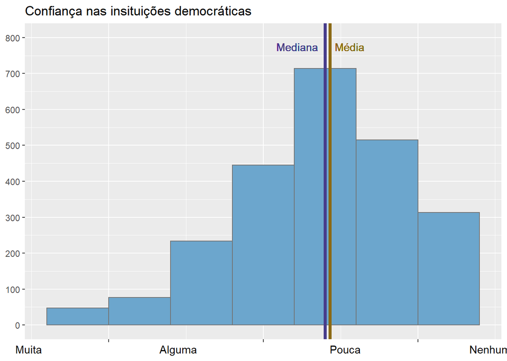

A seguir podemos está disposto o Gráfico 2 que mostra a confiança nas Forças Armadas, também disposto de muita confiança a nenhuma confiança. A partir deles, pode-se verificar uma clara tendência de não confiar nas instituições por boa parte do eleitorado, ao passo que existe uma forte confiança nas Forças Armadas.

**GRÁFICO 2 - CONFIANÇA NAS FFAA X VOTO EM JB**

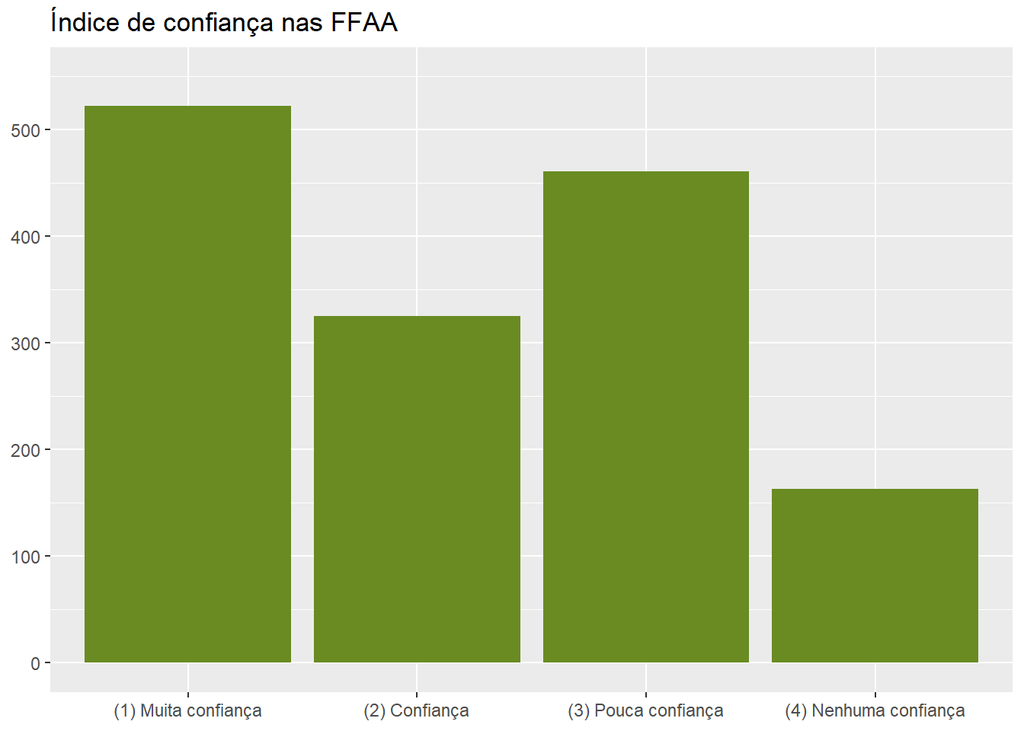

Os gráficos oriundos da regressão logística utilizada para observar a relação entre as percepções dos indivíduos sobre a democracia e suas instituições apontam a significância estatística de cada variável dependente, a razão de chances do aumento no valor de cada variável independente levar ao voto em Bolsonaro (odds ratio) e desvio padrão de cada variável explicativa. Os níveis de significância de cada variável no modelo é descrito pelos número de asteriscos nela, quanto mais asteriscos, mais significante ela é. A razão de chances é ilustrada pelo ponto central em cada reta horizontal e quanto mais distante ele está de 1 (indicado pela linha vertical em vermelho) maior é a relação daquela variável com a variável dependente, podendo ser uma associação negativa quando valor é inferior a 1 e positiva quando é superior. O desvio padrão é indicado pelas retas horizontais e quanto mais extensas elas são, maior é o desvio padrão.

**GRÁFICO 3 - CHANCES DE VOTO NO 1° TURNO**

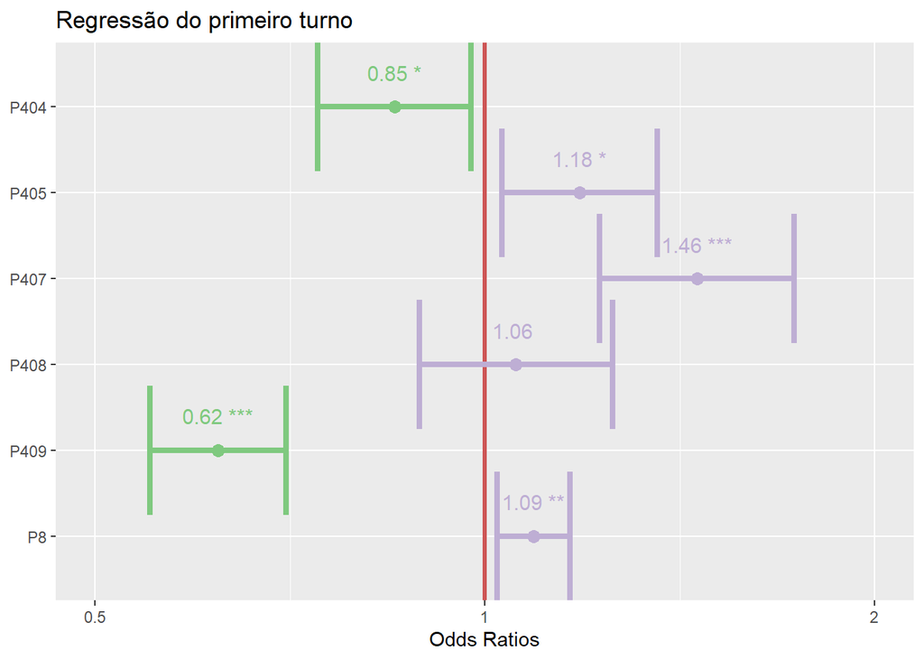

**GRÁFICO 4 - CHANCES DE VOTO EM 2° TURNO**

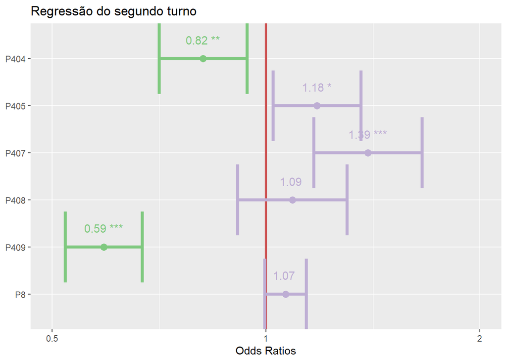

Confiança no governo federal possui uma associação negativa e com considerável significância no modelo, indicando que aqueles que votaram em Bolsonaro tendem a confiar mais no governo federal. Isso está de acordo com as expectativas, tendo em vista que esse é o poder mais centralizado dentro das democracias presidencialistas e que o candidato apoiado pelo respondente foi eleito.

A confiança no judiciário, no Congresso Nacional e nos partidos políticos obtiveram uma associação positiva com o voto em Bolsonaro, sendo a variável P407 - referente à confiança nos partidos políticos, a mais representativa do modelo. Entretanto, a variável P408 que avalia a confiança no Congresso Nacional não obteve significância suficiente para podermos fazer inferências estatística seguras por meio dela. Já a (não) confiança nos partidos políticos e no judiciário, obtiveram significância o suficiente para a interpretação de seus valores. Assim, podemos confirmar nossa hipótese de que pessoas que não confiam nas instituições centrais da democracia tem mais afinidade com Bolsonaro.

Já a confiança nas forças armadas apresentou uma forte relação negativa com o voto em Bolsonaro, bem com uma alta significância estatística. Somando este fato aos resultados apontados até aqui, verifica-se que os eleitores de Bolsonaro tendem a confiar mais nas forças armadas do que nas instituições basais da democracia. Esta é uma tendência bastante lógica ao considerarmos os posicionamentos de Bolsonaro em relação a essas instituições, que, como já tratado na introdução, sempre se mostrou como um defensor da ditadura militar e crítico do governo democrático.

### CONCLUSÕES

Do exposto, fica evidente que uma maior compreensão sobre o perfil do eleitorado torna-se mister aos que se lançam analisar a ascensão de lideranças carismáticas ao poder. Compreendê-las permite avaliar não só o grau de comprometimento da sociedade com as premissas democráticas do sistema representativo, mas também o eco que discursos e narrativas produzem sobre o ambiente social.

A eleição vitoriosa de Jair Bolsonaro movimentou o pêndulo da política para o lado direito, e fez emergir discursos e insatisfações que colocam em xeque o próprio sistema democrático, motivo pelo qual a análise minuciosa dos dados eleitorais do Brasil torna-se tarefa indispensável aos que se lançam a compreender as ondas de alternância de poder.

Por fim, é inegável que a população pediu por mudança nas eleições majoritárias de 2018, especialmente a eleição presidencial, motivo pelo qual os defensores da democracia e seus valores devem compreender os anseios populares, buscando nessa própria insatisfação manifestada no pleito as bases para a mudança de perspectiva que fortaleçam, e nao o contrário, o sistema representativo democrático.